# Geographic Visualization of Gun Violence in the U.S.

Bich Ngoc Nguyen, Felix Ung, Anna Voloshina, Delaney Wu

1/12/2022

## **Table**

### **Table of Summary**

|  | V1 |
| --- | --- |
| Number of Observations | 239677 |
| Total Deaths | 60468 |
| State with Most Total Deaths | California |
| State with Least Total Deaths | Vermont |
| City with Most Total Deaths | Chicago, Illinois |
| Cities with Least Total Deaths (0) | 8536 |
| Year with Most Deaths | 2017 |
| Year with Least Deaths | 2013 |
| Date with Most Deaths | 11/5/2017 |
| Dates with Lead Deaths (0) | 57 |

## **Charts**

### **Visualization of Total Gun Violence Incidence by State (2013-2018)**

The purpose of the chart below is to provide a visualized comparison of the amount deaths caused by gun violence across different state from 2013 to 2018. According to the chart California and Texas are the states with the most deaths caused by gun violence.

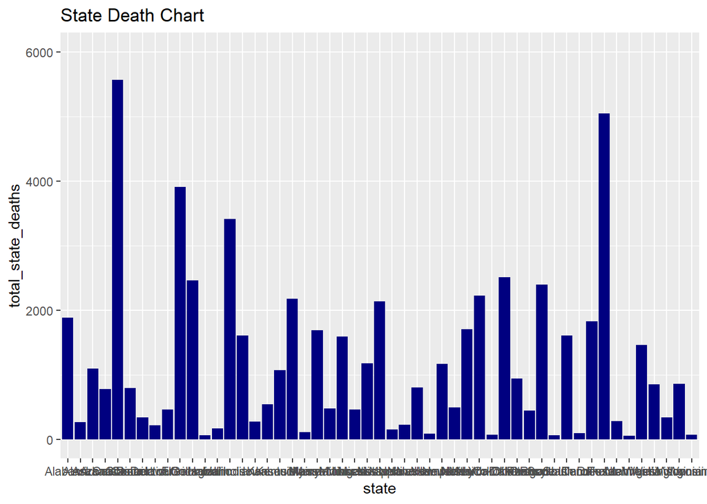

**note** In the final report, we’ll attempt to make the map more interactive by letting user select multiple state of their choosing and only displaying those.

### **Visualization of Total Gun Violence Incidence by City (2013-2018)**

The map below displays an interactive map of a state and its cities with the corresponding deaths as a result of gun violence. One observation according to the map, is that gun violence incidences and gun deaths tend to appear in large cities and in close proximity to main highways and interstates.

[interactive chart not shown]

**note** In the final report, we’ll attempt to make the map more interactive by letting user select a state of their choosing and displaying the cities within it.

### **Gun Violence Distribution by State in 2016**

The map below shows the distribution of gun deaths across different states within the US in the year 2016. According to the map, California and Texas had the most gun deaths, followed by Illinois and Florida. Overall, the eastern United states seems to have more gun deaths compare to other regions like the north west.

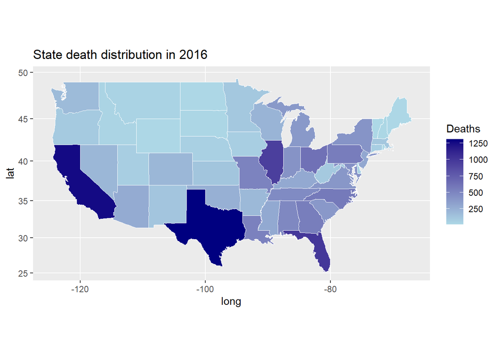

**note** In the final report, we’ll attempt to make the map more interactive by allowing user to change the time frame (2013-2018) by year and month.